# Problem Set 5

## About this file

This is the Yicun Duan’s (umich id: 62178151) report of STAT 506’s Problem Set 5. Here is the link to my [GitHub repository](https://github.com/YicunDuanUMich/r_hw05).

## Problem 1 - Plotting

### a

We first preprocess the data to get the average temperature for each month in celsius.

**Preprocess data**

```r
rm(list = ls())
library(tidyverse)
```

**Preprocess data**

```r
# Read data from csv and preprocess the variables.
nnmaps <- read.csv("./data/chicago-nmmaps.csv")
nnmaps$date <- as.Date(nnmaps$date)
nnmaps$season <- factor(nnmaps$season, levels = c("Winter", "Spring",
                                                     "Summer", "Autumn"))
# Transfer data.frame to tibble.
nnmaps <- as_tibble(nnmaps)

# Calculate the average temperature/o3/dewpoint/pm10 by month.
# Change the unit of temperature to celsius.
nnmaps <- nnmaps %>%
  group_by(month_numeric) %>%
  summarise(temp_month_avg = mean(temp, na.rm = TRUE),
            o3_month_avg = mean(o3, na.rm = TRUE),
            dewpoint_month_avg = mean(dewpoint, na.rm = TRUE),
            pm10_month_avg = mean(pm10, na.rm = TRUE),
            season = unique(season)) %>%
  ungroup() %>%
  mutate(temp_month_avg = (temp_month_avg - 32) * (5 / 9))
```

We load the theme from this [link](https://rpubs.com/Koundy/71792) to make the plot publication-ready.

**Load the theme**

```r
# code from https://rpubs.com/Koundy/71792

# Define the theme.
theme_for_pub <- function(base_size=10, base_family="helvetica") {
      library(grid)
      library(ggthemes)
      (theme_foundation(base_size=base_size, base_family=base_family)
       + theme(plot.title = element_text(face = "bold",
                                         size = rel(1.2), hjust = 0.5),
               text = element_text(),
               panel.background = element_rect(colour = NA),
               plot.background = element_rect(colour = NA),
               panel.border = element_rect(colour = NA),
               axis.title = element_text(face = "bold", size = rel(1)),
               axis.title.y = element_text(angle=90, vjust =2),
               axis.title.x = element_text(vjust = -0.2),
               axis.text = element_text(),
               axis.line = element_line(colour = "black"),
               axis.ticks = element_line(),
               panel.grid.major = element_line(colour = "#f0f0f0"),
               panel.grid.minor = element_blank(),
               legend.key = element_rect(colour = NA),
               legend.position = "bottom",
               legend.direction = "horizontal",
               legend.key.size= unit(0.2, "cm"),
               legend.spacing = unit(0, "cm"),
               legend.title = element_text(face="italic"),
               plot.margin=unit(c(10,5,5,5),"mm"),
               strip.background=element_rect(colour = "#f0f0f0",fill = "#f0f0f0"),
               strip.text = element_text(face="bold")
          ))

}

# Define the fill color.
scale_fill_for_pub <- function(...){
      library(scales)
      discrete_scale("fill", "Publication",
                     manual_pal(values = c("#386cb0", "#7fc97f", "#ef3b2c", "#fdb462","#662506","#a6cee3","#fb9a99","#984ea3","#ffff33")), ...)

}

# Define the color.
scale_colour_for_pub <- function(...){
      library(scales)
      discrete_scale("colour", "Publication",
                     manual_pal(values = c("#386cb0", "#7fc97f", "#ef3b2c", "#fdb462","#662506","#a6cee3","#fb9a99","#984ea3","#ffff33")), ...)

}
```

We use `ggplot` to show the monthly average temperature in celsius.

**Plot**

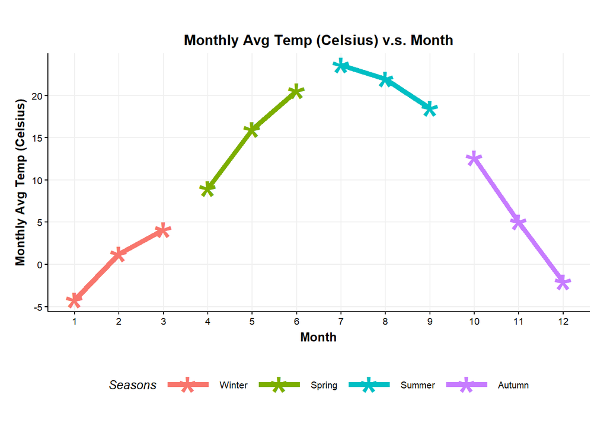

```r
ggplot(data = nnmaps,
       mapping = aes(x = month_numeric, y = temp_month_avg, color = season)) +
  geom_line(linewidth = 2) +
  geom_point(shape = "*", size = 15) +
  ggtitle("Monthly Avg Temp (Celsius) v.s. Month") +
  scale_x_discrete(name = "Month", limits = factor(1:12)) +
  scale_y_continuous(name = "Monthly Avg Temp (Celsius)") +
  scale_colour_for_pub() + theme_for_pub() +
  scale_color_discrete(name = "Seasons")
```

### b

We pivot the data, and also change the names of data type (e.g., from `temp_month_avg` to `Temperature (Celsius)`) for the convenience of plotting.

**Preprocess data**

```r
# Pivot longer and change the name.
nnmaps <- nnmaps %>% pivot_longer(cols = temp_month_avg:pm10_month_avg,
                        names_to = "type", values_to = "data") %>%
          mutate(type = sapply(type, function(x) {
                              switch(x,
                                     temp_month_avg = "Temperature (Celsius)",
                                     o3_month_avg = "O3",
                                     dewpoint_month_avg = "Dewpoint",
                                     pm10_month_avg = "PM10"
                                     )
            }))
```

In the following graph, we showcase the per month average Temperature/O3/PM10/Dewpoint. We use different point shapes and line shapes to distinguish the data types. Different colors are used to differ the seasons. As shown in the graph, `PM10` has the least seasonal trend.

**Plot**

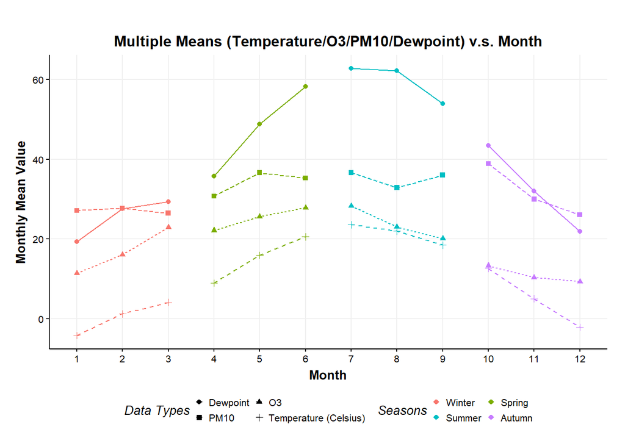

```r
ggplot(data = nnmaps,
        mapping = aes(x = month_numeric, y = data, color = season)) +
        geom_line(mapping = aes(linetype = type), line_width = 4) +
        geom_point(mapping = aes(shape = type)) +
        ggtitle("Multiple Means (Temperature/O3/PM10/Dewpoint) v.s. Month") +
        scale_x_discrete(name = "Month", limits = factor(1:12)) +
        scale_y_continuous(name = "Monthly Mean Value")  +
        scale_colour_for_pub() + theme_for_pub() +
        guides(shape = guide_legend(nrow = 2, byrow = TRUE),
               linetype = guide_legend(nrow = 2, byrow = TRUE),
               color = guide_legend(nrow=2, byrow=TRUE)) +
        scale_shape_discrete(name = "Data Types") +
        scale_linetype(name = "Data Types") +
        scale_color_discrete(name = "Seasons")
```

## Problem 2 - OOP Programming

### a

We first define the class and validator.

**Class and Validator**

```r
rm(list = ls())

# We define the `poly` class whose attribute is a `data.frame`.
# This `data.frame` should contain two columns (`power` and `poly_coef`).
# The column `power` stores the power of each term.
# The column `poly_coef` stores the coefficient of each term.
setClass("poly",
         slots = c(data = "data.frame"))


#' The validator of the `poly` class.
#'
#' It will check the column name of the `data.frame` in `poly`.
#' It will also verify the data type and values.
#'
#' @param object the `poly` object
#'
#' @return whether the object is valid.
setValidity("poly", function(object) {
  # The `data.frame` should contain two columns (`power` and `poly_coef`).
  # The column `power` stores the power of each term.
  # The column `poly_coef` stores the coefficient of each term.
  if (!all(c("power", "poly_coef") %in% colnames(object@data))) {
    stop("The `data` of `poly` class should have columns `power` and `poly_coef`")
  }

  # The column `power` and `poly_coef` should be numeric vectors.
  if (!(is.numeric(object@data$power) && is.numeric(object@data$poly_coef))) {
    stop("The `power` and `poly_coef` of `poly`'s `data` attribute should be numeric vectors.")
  }

  # The column `power` should not contain NaN, NA and Inf.
  if (any(is.nan(object@data$power) |
          is.na(object@data$power) |
          is.infinite(object@data$power))) {
    stop("The `power` of `poly`'s `data` attribute contains `NaN`, `NA`, or `Inf`.")
  }

  # The column `poly_coef` should not contain NaN, NA and Inf.
  if (any(is.nan(object@data$poly_coef) |
          is.na(object@data$poly_coef) |
          is.infinite(object@data$poly_coef))) {
    stop("The `poly_coef` of `poly`'s `data` attribute contains `NaN`, `NA`, or `Inf`.")
  }

  # The column `power` should not contain repeated values.
  if (length(unique(object@data$power)) != length(object@data$power)) {
    stop("The `power` of `poly`'s `data` attribute contains repeated values.")
  }

  return(TRUE)
})
```

```
Class "poly" [in ".GlobalEnv"]

Slots:

Name:        data
Class: data.frame
```

We define the constructor as follows:

**Constructor**

```r
#' The constructor of `poly` class.
#'
#' It takes a named numeric vector as input.
#' The names of this vector should be like `x1`, `x4`, `x1.2`, `intercept`.
#' The values of this vector refer to the coefficients of each term and
#' can be any real number.
#'
#' @param poly_express a named numeric vector which represents the polynomial expression.
make_poly <- function(poly_express) {
  # Check whether the input is a named numeric vector.
  if (!is.numeric(poly_express) ||
      is.null(names(poly_express))
      ) {
    stop("The input `poly_express` should be a named numeric vector")
  }

  # Store the names into `poly_names`, and check whether the names are valid.
  poly_names <- names(poly_express)
  if (!all(grepl("^[xX]", poly_names) | poly_names %in% "intercept")) {
    stop("The input vector should have names like `x1`, `x1.2` and `intercept`.")
  }
  # If the name is `x`, we treat it as `x1`.
  if ("x" %in% poly_names) {
    poly_names[which(poly_names %in% "x")] <- "x1"
  }
  # If the name is `intercept`, we treat it as `x0`.
  if ("intercept" %in% poly_names) {
    poly_names[which(poly_names %in% "intercept")] <- "x0"
  }

  # Drop the first character of the names.
  poly_names_trunc <- sapply(poly_names, function(x) {
    return(substr(x, 2, nchar(x)))
  })

  # Check whether the powers are valid numbers.
  if (any(is.na(
    suppressWarnings(
      as.numeric(poly_names_trunc)
      )
    ))) {
    stop("The input vector should have names like `x1`, `x1.2` and `intercept`.")
  }

  # Get the power of each term.
  poly_names_val <- as.numeric(poly_names_trunc)
  # Get the coefficient of each term.
  poly_coef <- unname(poly_express)
  # Create a `data.frame` to store the powers and coefficients.
  poly_data_frame <- data.frame(power = poly_names_val,
                                poly_coef = poly_coef)
  # Combine the coefficients of the terms with same power.
  poly_data_frame <- aggregate(poly_data_frame$poly_coef,
                               by = list(poly_data_frame$power),
                               FUN = sum)
  colnames(poly_data_frame) <- c("power", "poly_coef")

  return(new("poly",
             data = poly_data_frame))
}
```

The `show` method of `poly` class:

```r
#' The `show` method of class `poly`.
#'
#' It will print a sting showing the polynomial expression.
#'
#' @param object a `poly` object.
#'
#' @return the input `poly` object.
setMethod("show", "poly", function(object) {
  # Sort the terms according to power.
  poly_sorted <- object@data[order(object@data$power, decreasing = TRUE), ]

  # Suppress the terms with coefficients of 0.
  if (any(poly_sorted$poly_coef == 0)) {
    poly_sorted <- poly_sorted[-which(poly_sorted$poly_coef == 0), ]
  }

  # Transfer powers and coefficients to string.
  poly_sorted_power_str <- as.character(poly_sorted$power)
  poly_sorted_abs_coef_str <- as.character(abs(poly_sorted$poly_coef))

  # Hide the coefficients whose values are 1.
  if ("1" %in% poly_sorted_abs_coef_str) {
    poly_sorted_abs_coef_str[which(poly_sorted_abs_coef_str %in% "1")] <- ""
  }
  # Get the sign of coefficients.
  poly_sorted_coef_sign_str <- ifelse(poly_sorted$poly_coef >= 0, "+", "-")

  # Create the output string.
  sign_abs_coef_str <- paste(poly_sorted_coef_sign_str, poly_sorted_abs_coef_str)
  output_str <- paste(sign_abs_coef_str, poly_sorted_power_str,
                      sep = "x^", collapse = " ")
  # Reduce `x^0` to 1.
  output_str <- gsub("x\\^0", "", output_str)
  # Reduce `x^1` to `x`.
  output_str <- gsub("x\\^1", "x", output_str)
  # If the output string begins with `+`, we hide this plus sign.
  if (substr(output_str, 1, 1) == "+") {
    output_str <- substr(output_str, 3, nchar(output_str))
  }
  # Print the string.
  cat(output_str, "\n")
  return(invisible(object))
})
```

In the following code, we define the addition and subtraction for the `poly` class.

**Addition and Subtraction**

```r
#' The addition method of `poly` class.
#'
#' It calculate the addition of two polynomial expressions.
#'
#' @param e1 the LHS `poly` object.
#' @param e2 the RHS `poly` object.
#'
#' @return the `poly` object of `e1` + `e2`
setMethod("+", signature(e1 = "poly", e2 = "poly"),
          function(e1, e2) {
            # Get the `data.frame` of `e1` and `e2`.
            e1_df <- e1@data
            e2_df <- e2@data

            # Merge the `data.frame` by power.
            output_df <- merge(e1_df, e2_df, by = "power",
                               all = TRUE)
            # Change NA to 0.
            output_df$poly_coef.x <- ifelse(is.na(output_df$poly_coef.x),
                                            0, output_df$poly_coef.x)
            output_df$poly_coef.y <- ifelse(is.na(output_df$poly_coef.y),
                                            0, output_df$poly_coef.y)

            # Conduct addition.
            output_df$poly_coef <- output_df$poly_coef.x + output_df$poly_coef.y

            # Delete useless columns.
            output_df$poly_coef.x <- NULL
            output_df$poly_coef.y <- NULL

            # Create a new `poly` object.
            return(new("poly", data = output_df))
          })


#' The subtraction method of `poly` class.
#'
#' It calculate the subtraction of two polynomial expressions.
#'
#' @param e1 the LHS `poly` object.
#' @param e2 the RHS `poly` object.
#'
#' @return the `poly` object of `e1` - `e2`
setMethod("-", signature(e1 = "poly", e2 = "poly"),
          function(e1, e2) {
            # Get the `data.frame` of `e1` and `e2`.
            e1_df <- e1@data
            e2_df <- e2@data

            # Merge the `data.frame` by power.
            output_df <- merge(e1_df, e2_df, by = "power",
                               all = TRUE)

            # Change NA to 0.
            output_df$poly_coef.x <- ifelse(is.na(output_df$poly_coef.x),
                                            0, output_df$poly_coef.x)
            output_df$poly_coef.y <- ifelse(is.na(output_df$poly_coef.y),
                                            0, output_df$poly_coef.y)

            # Conduct subtraction.
            output_df$poly_coef <- output_df$poly_coef.x - output_df$poly_coef.y

            # Delete useless columns.
            output_df$poly_coef.x <- NULL
            output_df$poly_coef.y <- NULL

            # Create a new `poly` object.
            return(new("poly", data = output_df))
          })
```

### b

We first conduct some basic tests and then test some special cases to show that our work can earn extra credit.

The basic tests:

**Basic tests**

```r
p1 <- make_poly(c(x2 = 3, intercept = 2))
p2 <- make_poly(c(x3 = 7, x2 = -2, x = -1, intercept = 17))
p1
```

```
3x^2 + 2
```

**Basic tests**

```r
p2
```

```
7x^3 - 2x^2 - x + 17
```

**Basic tests**

```r
p1 + p2
```

```
7x^3 + x^2 - x + 19
```

**Basic tests**

```r
p1 - p2
```

```
- 7x^3 + 5x^2 + x - 15
```

For **extra credit** (reducing $x^1$ and $x^0$ to $x$ and $1$ as appropriate):

**Extra credit (1)**

```r
p3 <- make_poly(c(x1 = 2, x0 = 3))
p3
```

```
2x + 3
```

For **extra credit** (suppressing terms with coefficients of 0):

**Extra credit (2)**

```r
p4 <- make_poly(c(x1 = 0, x2 = 3))
p4
```

```
3x^2
```

For **extra credit** (supporting negative and non-integer exponents):

**Extra credit (3)**

```r
p5 <- make_poly(c("x-1" = 1, "x-2.3" = 3))
p5
```

```
x^-1 + 3x^-2.3
```

## Problem 3 - `data.table`

### a

We generate two tables. One reports the mean and median departure delay per airport. Another shows the mean and median arrival delay per airport.

**Preparation**

```r
rm(list = ls())

library(data.table)
library(nycflights13)

data("flights")
data("airports")
data("planes")

flights <- as.data.table(flights)
airports <- as.data.table(airports)
planes <- as.data.table(planes)
```

The following table shows the mean and median departure delay per airport.

**The mean and median departure delay**

```r
dep_mean_med <- flights[, .(mean_delay = mean(dep_delay, na.rm = TRUE),
                              med_delay = median(dep_delay, na.rm = TRUE),
                              numflights = .N), by = origin] |>
                    _[numflights >= 10, ] |>
                    setnames(x = _, old = "origin", new = "faa") |>
                    merge(x = _, y = airports, by = "faa", all.x = TRUE) |>
                    _[order(-mean_delay), .(name, mean_delay, med_delay)]

print(dep_mean_med, n = nrow(dep_mean_med))
```

```
                  name mean_delay med_delay
1: Newark Liberty Intl   15.10795        -1
2: John F Kennedy Intl   12.11216        -1
3:          La Guardia   10.34688        -3
```

The following table shows the mean and median arrival delay per airport.

**The mean and median arrival delay**

```r
coalesce <- function(x, y) {
  return(ifelse(!is.na(x), x, y))
}

arr_mean_med <- flights[, .(mean_delay = mean(arr_delay, na.rm = TRUE),
                              med_delay = median(arr_delay, na.rm = TRUE),
                              numflights = .N), by = dest] |>
                    _[numflights >= 10, ] |>
                    setnames(x = _, old = "dest", new = "faa") |>
                    merge(x = _, y = airports, by = "faa", all.x = TRUE) |>
                    _[, name := coalesce(name, faa)] |>
                    _[order(-mean_delay), .(name, mean_delay, med_delay)]

print(arr_mean_med, n = nrow(arr_mean_med))
```

```
                                     name   mean_delay med_delay
  1:                Columbia Metropolitan  41.76415094      28.0
  2:                           Tulsa Intl  33.65986395      14.0
  3:                    Will Rogers World  30.61904762      16.0
  4:                 Jackson Hole Airport  28.09523810      15.0
  5:                        Mc Ghee Tyson  24.06920415       2.0
  6:               Dane Co Rgnl Truax Fld  20.19604317       1.0
  7:                        Richmond Intl  20.11125320       1.0
  8:        Akron Canton Regional Airport  19.69833729       3.0
  9:                      Des Moines Intl  19.00573614       0.0
 10:                   Gerald R Ford Intl  18.18956044       1.0
 11:                      Birmingham Intl  16.87732342      -2.0
 12:         Theodore Francis Green State  16.23463687       1.0
 13: Greenville-Spartanburg International  15.93544304      -0.5
 14:    Cincinnati Northern Kentucky Intl  15.36456376      -3.0
```

[output cut: 89 more lines]

### b

We find that 777-222 has the fastest average speed and it takes 4 flights.

**The fastest model**

```r
fastest_model <- merge(flights, planes, by = "tailnum", all.x = TRUE) |>
  _[, time := air_time / 60] |>
  _[, mph := distance / time] |>
  _[, .(avgmph = mean(mph, na.rm = TRUE),
        numflights = .N), by = model] |>
  _[order(-avgmph), ] |>
  _[1, ]

fastest_model
```

```
     model   avgmph numflights
1: 777-222 482.6254          4
```